# Appendix 2 STA206 Final Project

Andrew T. Weakley

11/23/2020

## — Step 1: Load and process the data —-

```r
## --- Part a: Upload Metadata for samples ---
META_DATA<-as_tibble(read.csv("IMPROVE_metadata.csv"))
## --- Filter samples based on living in SW ---
# --- Consider only AZ and NM for simplicity
# (Definition of American  "Southwest" varies by source. However, AZ and NM are always included.
SW_META<-as_tibble(META_DATA %>% filter(State =="AZ" | State =="NM"))
SW_META
```

```
## # A tibble: 30 x 19
##    Site  Code  Dataset Country State County AQSCode Latitude Longitude Elevation
##    <chr> <chr> <chr>   <chr>   <chr>  <int>   <int>    <dbl>     <dbl>     <int>
##  1 Band~ BAND1 IMPAER  US      NM     35028  3.50e8     35.8     -106.      1988
##  2 Bosq~ BOAP1 IMPAER  US      NM     35053  3.51e8     33.9     -107.      1389
##  3 Carl~ CAVE1 IMPAER  US      NM     35015 NA          32.2     -104.      1355
##  4 Chir~ CHIR1 IMPAER  US      AZ      4003  4.00e7     32.0     -109.      1554
##  5 Doug~ DOUG1 IMPAER  US      AZ      4003  4.00e7     31.3     -110.      1230
##  6 Gila~ GICL1 IMPAER  US      NM     35003  3.50e8     33.2     -108.      1775
##  7 Hanc~ GRCA2 IMPAER  US      AZ      4005  4.01e7     36.0     -112.      2267
##  8 Hill~ HILL1 IMPAER  US      AZ      4025  4.03e7     34.4     -113.      1510
##  9 Hopi~ GRCA1 IMPAER  US      AZ      4005  4.01e7     36.1     -112.      2164
## 10 Ike'~ IKBA1 IMPAER  US      AZ      4025  4.03e7     34.3     -112.      1297
## # ... with 20 more rows, and 9 more variables: StartDate <chr>, EndDate <chr>,
## #   DemographicCode <chr>, LandUseCode <chr>, StreetAddress <chr>,
## #   LocDesc <chr>, Sponsor <chr>, ProgramKey <chr>, NumPOCs <int>
```

```r
## --- Part b: Load samples data ---
DATA<-as_tibble(read.csv("IMPROVE_2015_data_w_UNC.csv"))

## --- Part c: Select samples from SW given site identifiers from SW_META table ("Code")
SW_DATA_all<-as_tibble(DATA %>% filter(SiteCode %in% SW_META$Code))
```

```r
# Let's identify any samples that (grossly) violate absorbance laws.
# fabs (=Y) cannot be negative. Remove samples that are < -3*UNC at zero absorbance... This is conservative as errors may make some absorbance <0 for small concentrations.
SW_DATA_all<-SW_DATA_all %>% dplyr::filter(fAbs > -3*fAbs_UNC)
```

```r
exclude<-c("PM2.5","PM10","POC","ammNO3","ammSO4","SeaSalt","OC1","OC2","OC3","OC4","EC1","EC2","EC3","fAbs_MDL")
SW_DATA_LRG<- SW_DATA_all %>% dplyr::select(!contains(exclude) & !matches("_UNC") | matches("fAbs_UNC"))
any(is.na(SW_DATA_LRG))
```

```
## [1] TRUE
```

```r
SW_DATA_LRG<-SW_DATA_LRG[which(complete.cases(SW_DATA_LRG)),]
any(is.na(SW_DATA_LRG))
```

```
## [1] FALSE
```

```r
X1<-c("SiteCode","Date","fAbs","EC","OC","SOIL","FE","AL","SI","CA","TI","OP","fAbs_UNC")
SW_DATA<-SW_DATA_LRG %>% dplyr::select(all_of(X1))
```

```r
## --- Instead of random partitioning, I will partition by first sorting samples by SiteCode and DATE (already done) and place every other sample in the test set.
# --- This data has seasonality. Sorting by date therefore ensures seasonality is equivalent between datasets
n<-nrow(SW_DATA)
ind_test<-seq(1,n,2)
SW_DATA_test<-SW_DATA[ind_test,]
SW_DATA<-SW_DATA[-ind_test,]
```

## — Step 2: Check correlations, descriptives —

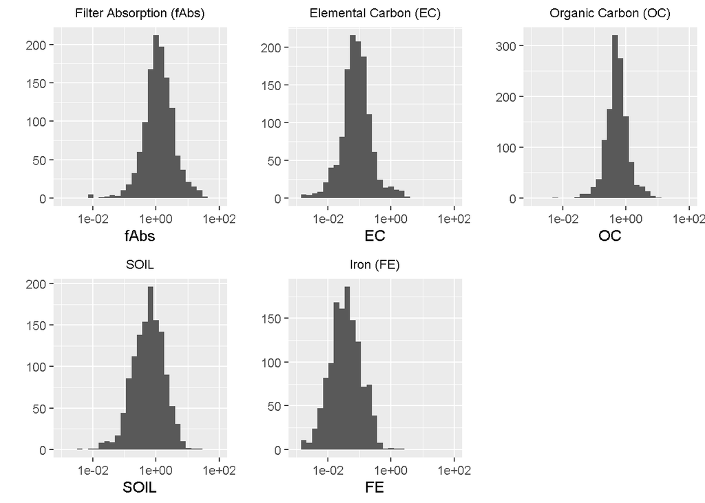

Figure (1) & A2.1: Histograms of theoretical best features

```r
H6<-qplot(fAbs, data = SW_DATA, main="Filter Absorption (fAbs)")+
  theme(plot.title = element_text(size=9,hjust = 0.5))+
  scale_x_log10(limits=c(0.001,100))
H7<-qplot(EC, data = SW_DATA, main="Elemental Carbon (EC)")+ theme(plot.title = element_text(size=9, hjust = 0.5))+
  scale_x_log10(limits=c(0.001,100))
H8<-qplot(OC, data = SW_DATA, main="Organic Carbon (OC)")+
  theme(plot.title = element_text(size=9, hjust = 0.5))+
  scale_x_log10(limits=c(0.001,100))
H9<-qplot(SOIL, data = SW_DATA, main="SOIL")+
  theme(plot.title = element_text(size=9, hjust = 0.5))+
  scale_x_log10(limits=c(0.001,100))
H10<-qplot(FE, data = SW_DATA, main="Iron (FE)")+
  theme(plot.title = element_text(size=9, hjust = 0.5))+
  scale_x_log10(limits=c(0.001,100))
grid.arrange(H6,H7,H8,H9,H10,nrow=2,ncol=3)
```

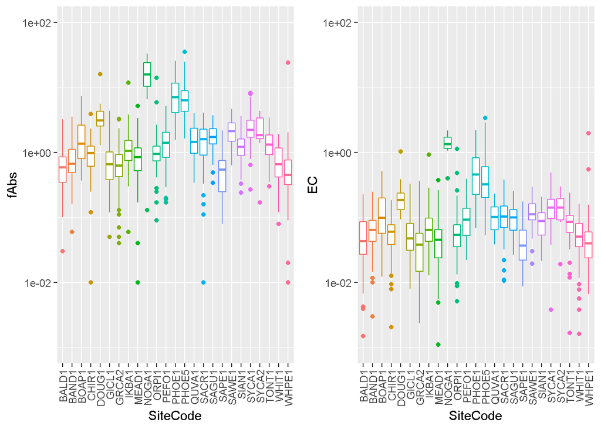

Figure (2.1) A2.2a: Aide-by-side Boxplots for fAbs and EC

```r
# --- Plot of abs and EC ---
H1<-ggplot(SW_DATA,aes(x=SiteCode,y=fAbs,color=SiteCode))+
  geom_boxplot()+
  theme(plot.title=element_text(hjust = 0.5))+
  scale_y_log10(limits=c(0.001,100))+
  theme(legend.position = "none",axis.text.x = element_text(angle = 90, vjust = 0.5, hjust=1))
H2<-ggplot(SW_DATA,aes(x=SiteCode,y=EC,color=SiteCode))+
  geom_boxplot()+
  theme(plot.title=element_text(hjust = 0.5))+
  scale_y_log10(limits=c(0.001,100))+
  theme(legend.position = "none",axis.text.x = element_text(angle = 90, vjust = 0.5, hjust=1))
# --- Plot of OC and SOIL ---
H3<-ggplot(SW_DATA,aes(x=SiteCode,y=OC,color=SiteCode))+
  geom_boxplot()+
  theme(plot.title=element_text(hjust = 0.5))+
  scale_y_log10(limits=c(0.001,100))+
  theme(legend.position = "none",axis.text.x = element_text(angle = 90, vjust = 0.5, hjust=1,size=5))
H4<-ggplot(SW_DATA,aes(x=SiteCode,y=SOIL,color=SiteCode))+
  geom_boxplot()+
  theme(plot.title=element_text(hjust = 0.5))+
  scale_y_log10(limits=c(0.001,100))+
  theme(legend.position = "none",axis.text.x = element_text(angle = 90, vjust = 0.5, hjust=1,size=5))

grid.arrange(H1,H2,nrow=1)
```

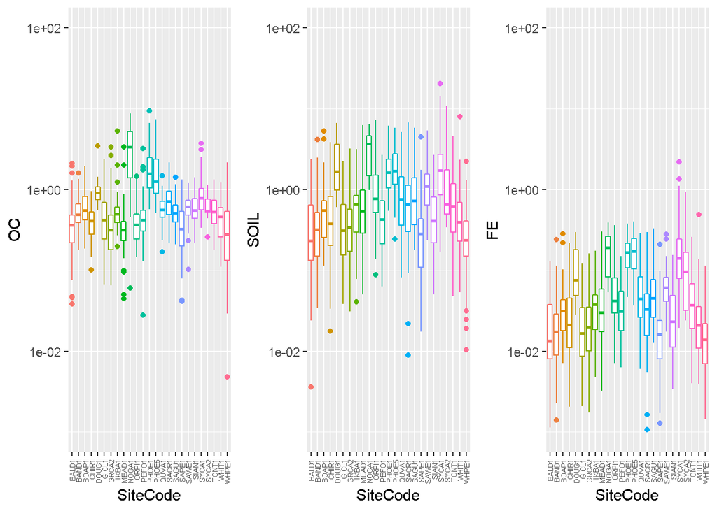

```r
# --- Iron plot ---
H5<-ggplot(SW_DATA,aes(x=SiteCode,y=FE,color=SiteCode))+
  geom_boxplot()+
  theme(plot.title=element_text(hjust = 0.5))+
  scale_y_log10(limits=c(0.001,100))+
  theme(legend.position = "none",axis.text.x = element_text(angle = 90, vjust = 0.5, hjust=1, size=5))

grid.arrange(H3,H4,H5,nrow=1)
```

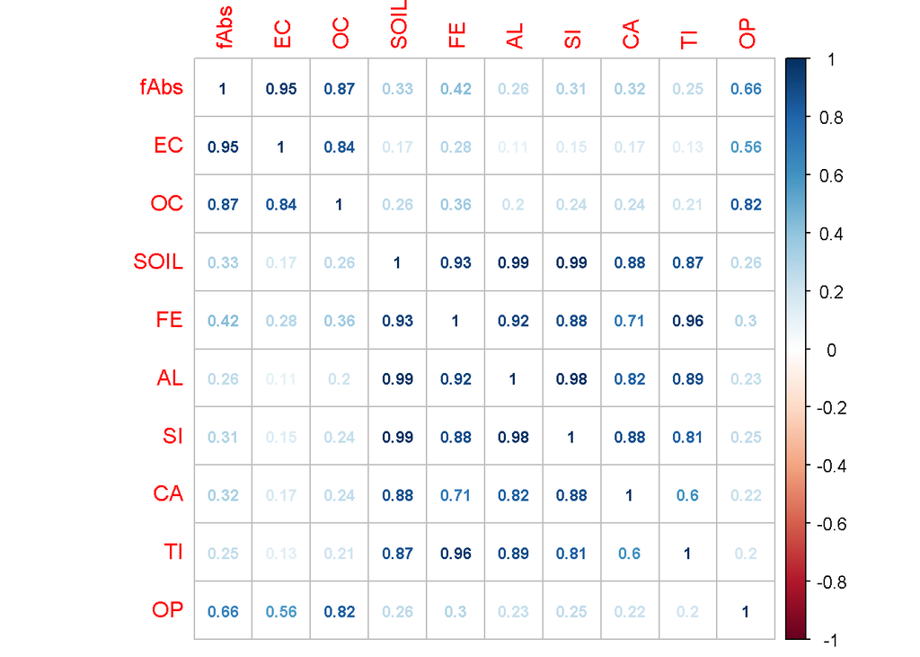

Figure A2.3: COrrelation plot

```r
R_FO<-cor(SW_DATA %>% dplyr::select(!all_of(c("SiteCode","Date","fAbs_UNC"))))
corrplot(R_FO, method="number",number.cex=0.75)
```

```r
describe(SW_DATA$fAbs)
```

```
## SW_DATA$fAbs
##        n  missing distinct     Info     Mean      Gmd      .05      .10
##     1264        0      476        1    2.157    2.484    0.120    0.280
##      .25      .50      .75      .90      .95
##    0.630    1.170    2.342    4.304    7.260
##
## lowest : -0.37 -0.35 -0.29 -0.28 -0.25, highest: 24.83 25.58 27.06 33.32 35.62
```

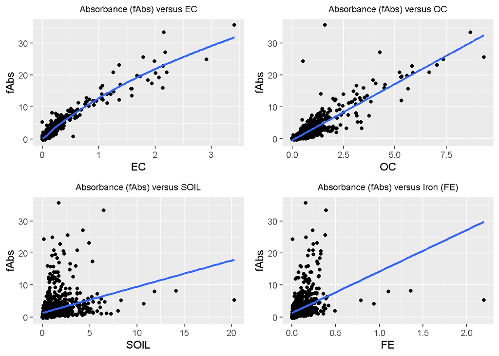

Figure (3) & A4: Scatter plots of fAbs against theoretical variables

```r
# --- Scatter plots of fAbs vs. Predictors (fancy)---
P1<-qplot(EC,fAbs, data = SW_DATA, main="Absorbance (fAbs) versus EC")+
  theme(plot.title = element_text(size=9,hjust = 0.5))+geom_smooth(se=FALSE)
P2<-qplot(OC,fAbs, data = SW_DATA, main="Absorbance (fAbs) versus OC")+
  theme(plot.title = element_text(size=9, hjust = 0.5))+geom_smooth(se=FALSE,method="lm")
P3<-qplot(SOIL,fAbs, data = SW_DATA, main="Absorbance (fAbs) versus SOIL")+
  theme(plot.title = element_text(size=9, hjust = 0.5))+geom_smooth(se=FALSE,method="lm")
P4<-qplot(FE,fAbs, data = SW_DATA, main="Absorbance (fAbs) versus Iron (FE)")+
  theme(plot.title = element_text(size=9, hjust = 0.5))+geom_smooth(se=FALSE,method="lm")
grid.arrange(P1,P2,P3,P4,nrow=2,ncol=2)
```

##### — Comment on scatter plots —

1. Appears to be two domains for FE (and SOIL) in their relation ship to fAbs
2. More importantly, linear absorbance laws appear to breakdown for EC — the main theoretical contributor to absorbance — at high concentration. This is a well known phenomenon and will likely require the inclusion of a polynomial approximation. Of course, the model becomes acausal (non-physical) at that point. But that’s OK, we are interested in prediction for this study.

## — Step 3: First order (additive) regression models —-

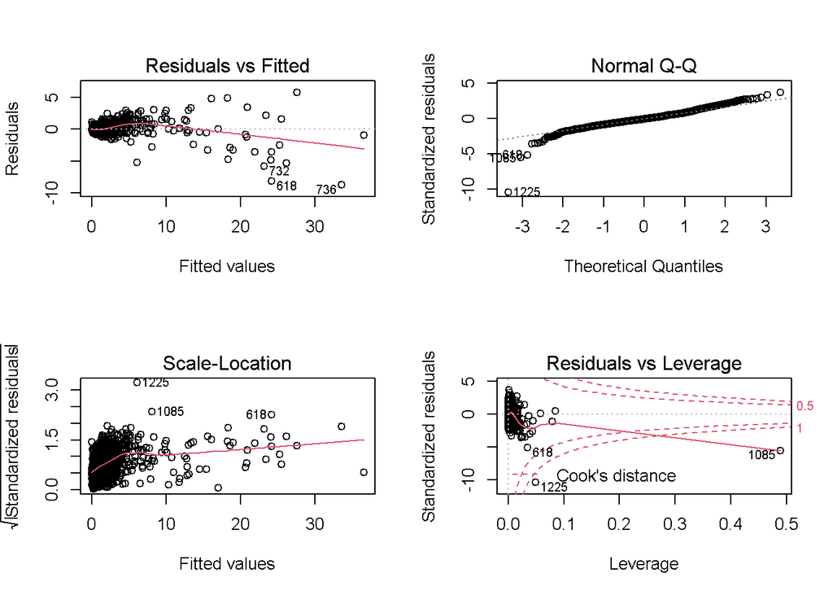

Figure A2.5: Diagnostics for ‘Theretical I’ model

```r
## --- Concerned mostly with determining effect for FE beyond SOIL, if any ---
## --- fAbs against EC,OC,SOIL,FE ---
fit_FO<-lm(fAbs~EC+OC+SOIL+FE-1,SW_DATA,weights=1/SW_DATA$fAbs_UNC^2)
par(mfrow=c(2,2))
plot(fit_FO)
```

```r
summary(fit_FO)
```

```
##
## Call:
## lm(formula = fAbs ~ EC + OC + SOIL + FE - 1, data = SW_DATA,
##     weights = 1/SW_DATA$fAbs_UNC^2)
##
## Weighted Residuals:
##     Min      1Q  Median      3Q     Max
## -32.895  -1.848  -0.133   1.801  11.940
##
## Coefficients:
##      Estimate Std. Error t value Pr(>|t|)
## EC   10.37224    0.21760  47.666  < 2e-16 ***
## OC    0.38965    0.04843   8.045 1.98e-15 ***
## SOIL  0.16417    0.03497   4.694 2.97e-06 ***
## FE    2.05485    0.49620   4.141 3.69e-05 ***
## ---
## Signif. codes:  0 '***' 0.001 '**' 0.01 '*' 0.05 '.' 0.1 ' ' 1
##
## Residual standard error: 3.242 on 1260 degrees of freedom
## Multiple R-squared:  0.9343, Adjusted R-squared:  0.9341
## F-statistic:  4479 on 4 and 1260 DF,  p-value: < 2.2e-16
```

```r
glance(fit_FO)
```

```
## # A tibble: 1 x 12
##   r.squared adj.r.squared sigma statistic p.value    df logLik   AIC   BIC
##       <dbl>         <dbl> <dbl>     <dbl>   <dbl> <dbl>  <dbl> <dbl> <dbl>
## 1     0.934         0.934  3.24     4479.       0     4 -1034. 2077. 2103.
## # ... with 3 more variables: deviance <dbl>, df.residual <int>, nobs <int>
```

```r
anova(fit_FO)
```

```
## Analysis of Variance Table
##
## Response: fAbs
##             Df Sum Sq Mean Sq   F value    Pr(>F)
## EC           1 178578  178578 16985.817 < 2.2e-16 ***
## OC           1   3837    3837   364.923 < 2.2e-16 ***
## SOIL         1   5750    5750   546.903 < 2.2e-16 ***
## FE           1    180     180    17.149 3.686e-05 ***
## Residuals 1260  13247      11
## ---
## Signif. codes:  0 '***' 0.001 '**' 0.01 '*' 0.05 '.' 0.1 ' ' 1
```

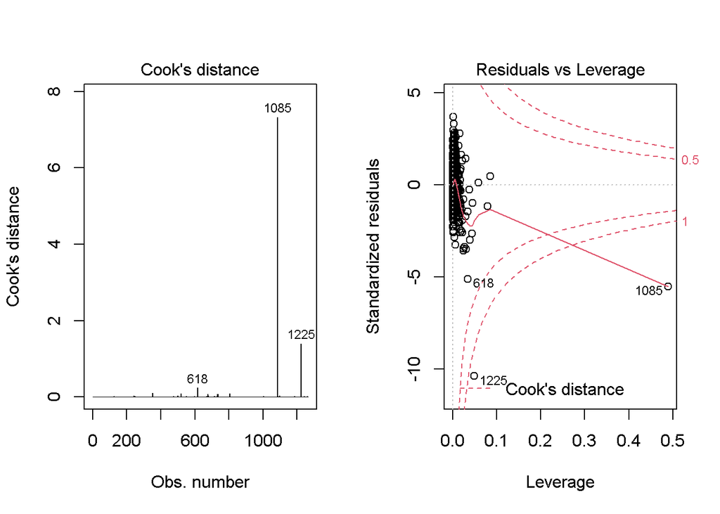

Figure A2.6: Cook’s distance and standardized residuals plots (zoomed in)

```r
## --- Let's just look at residuals ---
# --- Let's look at cook'sd distance...
par(mfrow=c(1,2))
plot(fit_FO, which=4)
plot(fit_FO, which=5)
```

```r
glance(fit_FO)
```

```
## # A tibble: 1 x 12
##   r.squared adj.r.squared sigma statistic p.value    df logLik   AIC   BIC
##       <dbl>         <dbl> <dbl>     <dbl>   <dbl> <dbl>  <dbl> <dbl> <dbl>
## 1     0.934         0.934  3.24     4479.       0     4 -1034. 2077. 2103.
## # ... with 3 more variables: deviance <dbl>, df.residual <int>, nobs <int>
```

### — COmments on model 1 —

1. A reasonable model overall; the residuals could use some work, i.e., perhaps we are missing some pertinent information with only these variables.
2. ONe possible explanation for the odd behavior of the standardized residuals might be related to the variable “OP”– which was not included in this model. OC and EC are actually defined operationally by a thermal analysis method that attempts to apportion the mass of carbon in each sample collected into either OC or EC. TO make a long story short, OP is a correction factor that’s neecesary to adjust the observed OC and EC as:
- EC = EC_unadj-OP
- OC =OC_unadj+OP. IN the next model, I would like to include OP in the model to determine if the fit improves; under the rationalle that there are some systematic errors in the OP correction factor.
3. Finally, FE explains little marginal SSR over and above SOIL. Probably indicating that FE can stand in for SOIL entirely (at least approximately). In other words, Fe in these samples is prodominantly associated wit Soil sources.

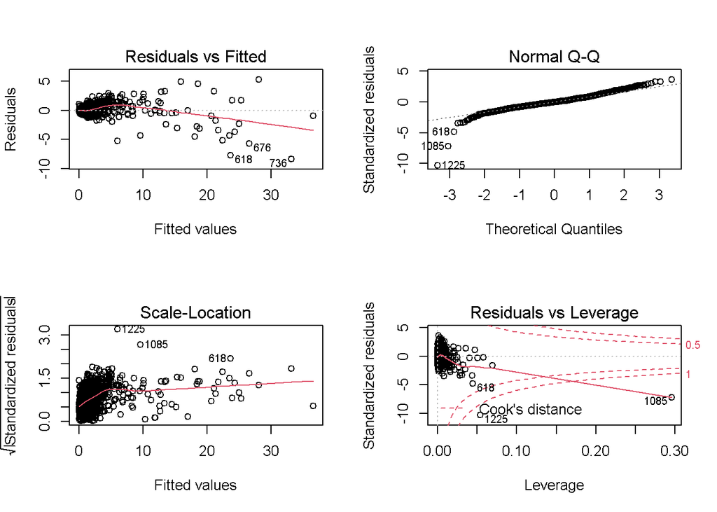

Figure A2.7: Diagnostics for ‘Theoretical II’ model (Fe for SOil, include OP)

```r
## --- fAbs against EC,OC,FE ---
fit_FO2<-lm(fAbs~EC+OC+FE+OP-1,SW_DATA,weights=1/SW_DATA$fAbs_UNC^2)
par(mfrow=c(2,2))
plot(fit_FO2)
```

```r
summary(fit_FO2)
```

```
##
## Call:
## lm(formula = fAbs ~ EC + OC + FE + OP - 1, data = SW_DATA, weights = 1/SW_DATA$fAbs_UNC^2)
##
## Weighted Residuals:
##     Min      1Q  Median      3Q     Max
## -32.724  -1.856  -0.118   1.807  11.721
##
## Coefficients:
##    Estimate Std. Error t value Pr(>|t|)
## EC 10.40776    0.23435  44.412   <2e-16 ***
## OC  0.23857    0.09628   2.478   0.0133 *
## FE  4.20506    0.18263  23.026   <2e-16 ***
## OP  0.82547    0.32218   2.562   0.0105 *
## ---
## Signif. codes:  0 '***' 0.001 '**' 0.01 '*' 0.05 '.' 0.1 ' ' 1
##
## Residual standard error: 3.262 on 1260 degrees of freedom
## Multiple R-squared:  0.9335, Adjusted R-squared:  0.9333
## F-statistic:  4421 on 4 and 1260 DF,  p-value: < 2.2e-16
```

```r
glance(fit_FO2)
```

```
## # A tibble: 1 x 12
##   r.squared adj.r.squared sigma statistic p.value    df logLik   AIC   BIC
##       <dbl>         <dbl> <dbl>     <dbl>   <dbl> <dbl>  <dbl> <dbl> <dbl>
## 1     0.933         0.933  3.26     4421.       0     4 -1041. 2093. 2118.
## # ... with 3 more variables: deviance <dbl>, df.residual <int>, nobs <int>
```

```r
## --- adjusted R^2 lower for this model than with SOIL! ---
```

```r
anova(fit_FO2)
```

```
## Analysis of Variance Table
##
## Response: fAbs
##             Df Sum Sq Mean Sq    F value  Pr(>F)
## EC           1 178578  178578 16780.8343 < 2e-16 ***
## OC           1   3837    3837   360.5189 < 2e-16 ***
## FE           1   5698    5698   535.4752 < 2e-16 ***
## OP           1     70      70     6.5645 0.01052 *
## Residuals 1260  13409      11
## ---
## Signif. codes:  0 '***' 0.001 '**' 0.01 '*' 0.05 '.' 0.1 ' ' 1
```

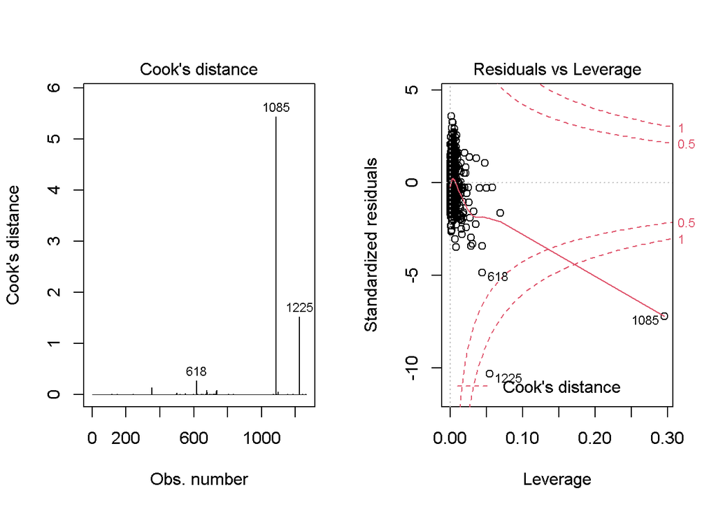

Figure A2.8: Cook’s Distance and Stand. resid. vs. leverage for ‘Theretical II’ model (zoomed in)

```r
## --- Let's just look at residuals ---
# --- Let's look at cook'sd distance...
par(mfrow=c(1,2))
plot(fit_FO2, which=4)
plot(fit_FO2, which=5)
```

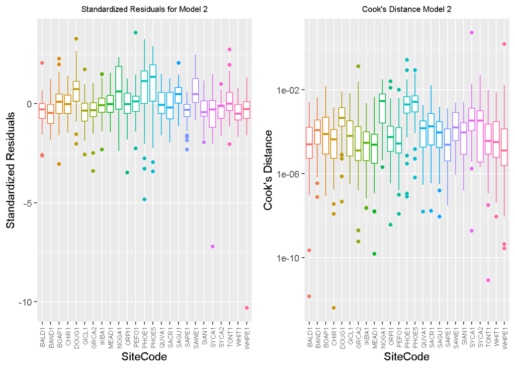

Figure A2.9: Side-by-Side box plots for standard. residuals and Cooks distance per SiteCode for ‘Theoretical II’ model

```r
## --- Let's look at side-by-side box-plots of fit residuals on a per site (SiteCode) basis ---
A2<-augment(fit_FO2) #Tidy extract fit diagnostic info
SW_DATA_A2<-add_column(SW_DATA,A2$.std.resid,A2$.cooksd)
# -- Perhaps some of our behavior is explained by sampling biases ---

Q1<-ggplot(SW_DATA_A2,aes(x=SiteCode,y=A2$.std.resid,color=SiteCode))+
  geom_boxplot()+
  theme(plot.title=element_text(hjust = 0.5,size=8))+
  theme(legend.position = "none",axis.text.x = element_text(angle = 90, vjust = 0.5, hjust=1,size=6))+ylab("Standardized Residuals")+ggtitle("Standardized Residuals for Model 2")
Q2<-ggplot(SW_DATA_A2,aes(x=SiteCode,y=A2$.cooksd,color=SiteCode))+
  geom_boxplot()+
  theme(plot.title=element_text(hjust = 0.5,size=8))+
  theme(legend.position = "none",axis.text.x = element_text(angle = 90, vjust = 0.5, hjust=1,size=6))+ylab("Cook's Distance")+scale_y_log10()+ggtitle("Cook's Distance Model 2")
grid.arrange(Q1,Q2,nrow=1)
```

### —- Part 4: Additive models with SiteCode as catagorical variable —-

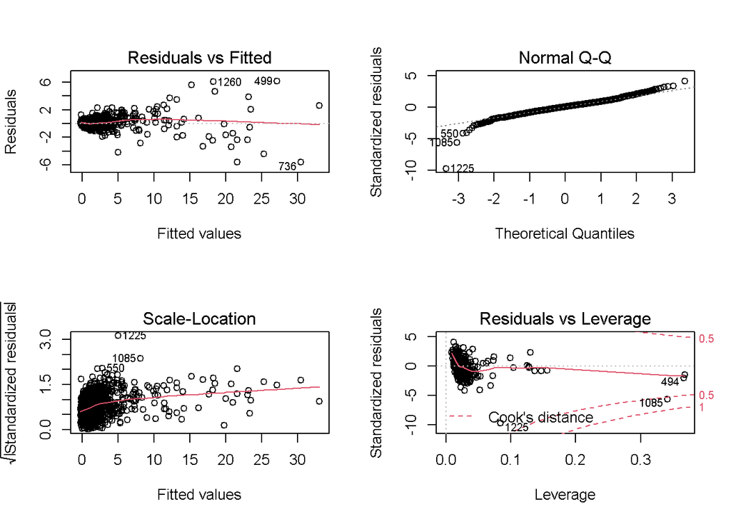

Figure A2.10: Diagnostics plots for ‘Theoretical III’ model

```r
## ---- Let's find a citation... ----
## ---- Categorical variable "SiteID" ----
fit_FO3<-lm(fAbs~EC+OC+FE+OP+SiteCode-1,SW_DATA,weights=1/SW_DATA$fAbs_UNC^2)
par(mfrow=c(2,2))
plot(fit_FO3)
```

```r
summary(fit_FO3)
```

```
##
## Call:
## lm(formula = fAbs ~ EC + OC + FE + OP + SiteCode - 1, data = SW_DATA,
##     weights = 1/SW_DATA$fAbs_UNC^2)
##
## Weighted Residuals:
##      Min       1Q   Median       3Q      Max
## -26.2793  -1.5137   0.1767   1.7107  11.5156
##
## Coefficients:
##                Estimate Std. Error t value Pr(>|t|)
## EC             8.989840   0.215641  41.689  < 2e-16 ***
## OC             0.195039   0.086470   2.256 0.024272 *
## FE             3.414402   0.178599  19.118  < 2e-16 ***
## OP             1.800597   0.311301   5.784 9.23e-09 ***
## SiteCodeBALD1 -0.187666   0.059091  -3.176 0.001531 **
## SiteCodeBAND1 -0.239980   0.062230  -3.856 0.000121 ***
## SiteCodeBOAP1  0.067969   0.068328   0.995 0.320053
## SiteCodeCHIR1 -0.018388   0.059644  -0.308 0.757908
## SiteCodeDOUG1  0.583438   0.082420   7.079 2.43e-12 ***
## SiteCodeGICL1 -0.244848   0.062505  -3.917 9.45e-05 ***
## SiteCodeGRCA2 -0.162494   0.059737  -2.720 0.006616 **
## SiteCodeIKBA1  0.005881   0.064590   0.091 0.927464
## SiteCodeMEAD1  0.024624   0.058639   0.420 0.674615
## SiteCodeNOGA1  0.506034   0.255910   1.977 0.048220 *
## SiteCodeORPI1  0.005458   0.059922   0.091 0.927441
## SiteCodePEFO1  0.105699   0.061814   1.710 0.087526 .
## SiteCodePHOE1  1.162059   0.104495  11.121  < 2e-16 ***
## SiteCodePHOE5  1.336221   0.102102  13.087  < 2e-16 ***
## SiteCodeQUVA1  0.054846   0.066022   0.831 0.406289
## SiteCodeSACR1 -0.065389   0.068348  -0.957 0.338899
## SiteCodeSAGU1  0.286192   0.064667   4.426 1.05e-05 ***
## SiteCodeSAPE1 -0.202290   0.063002  -3.211 0.001358 **
## SiteCodeSAWE1  0.404502   0.067116   6.027 2.20e-09 ***
## SiteCodeSIAN1 -0.118425   0.077195  -1.534 0.125262
## SiteCodeSYCA1 -0.031470   0.085184  -0.369 0.711864
## SiteCodeSYCA2  0.099239   0.162857   0.609 0.542398
## SiteCodeTONT1  0.103935   0.062497   1.663 0.096556 .
## SiteCodeWHIT1 -0.203231   0.060130  -3.380 0.000748 ***
## SiteCodeWHPE1 -0.238554   0.064171  -3.717 0.000210 ***
## ---
## Signif. codes:  0 '***' 0.001 '**' 0.01 '*' 0.05 '.' 0.1 ' ' 1
##
## Residual standard error: 2.816 on 1235 degrees of freedom
## Multiple R-squared:  0.9514, Adjusted R-squared:  0.9503
## F-statistic:   834 on 29 and 1235 DF,  p-value: < 2.2e-16
```

```r
glance(fit_FO3)
```

```
## # A tibble: 1 x 12
##   r.squared adj.r.squared sigma statistic p.value    df logLik   AIC   BIC
##       <dbl>         <dbl> <dbl>     <dbl>   <dbl> <dbl>  <dbl> <dbl> <dbl>
## 1     0.951         0.950  2.82      834.       0    29  -843. 1745. 1900.
## # ... with 3 more variables: deviance <dbl>, df.residual <int>, nobs <int>
```

```r
#augment(fit_FO2)

## --- Indeed. This model is far better now that a factor of "siteCode" is included. As expected, not all sites have significant intercepts, which makes sense given the preceeding plot.
```

```r
anova(fit_FO3)
```

```
## Analysis of Variance Table
##
## Response: fAbs
##             Df Sum Sq Mean Sq    F value    Pr(>F)
## EC           1 178578  178578 22517.8755 < 2.2e-16 ***
## OC           1   3837    3837   483.7734 < 2.2e-16 ***
## FE           1   5698    5698   718.5438 < 2.2e-16 ***
## OP           1     70      70     8.8088  0.003056 **
## SiteCode    25   3614     145    18.2308 < 2.2e-16 ***
## Residuals 1235   9794       8
## ---
## Signif. codes:  0 '***' 0.001 '**' 0.01 '*' 0.05 '.' 0.1 ' ' 1
```

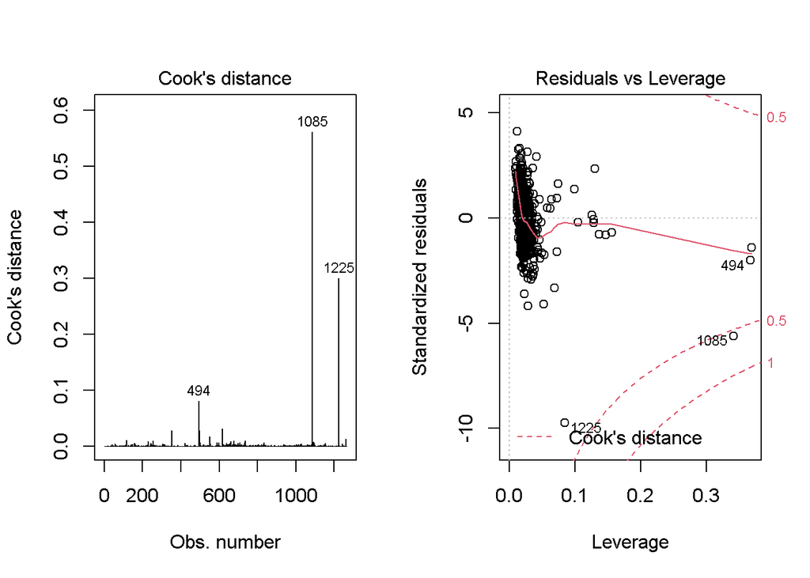

Figure A2.11: Core diagnostics plots for ‘Theoretical III’ model (zoomed in)

```r
## --- Let's just look at residuals ---
# --- Let's look at cook's distance...
par(mfrow=c(1,2))
#plot(fit_FO3, which=1)
plot(fit_FO3, which=4)
plot(fit_FO3, which=5)
```

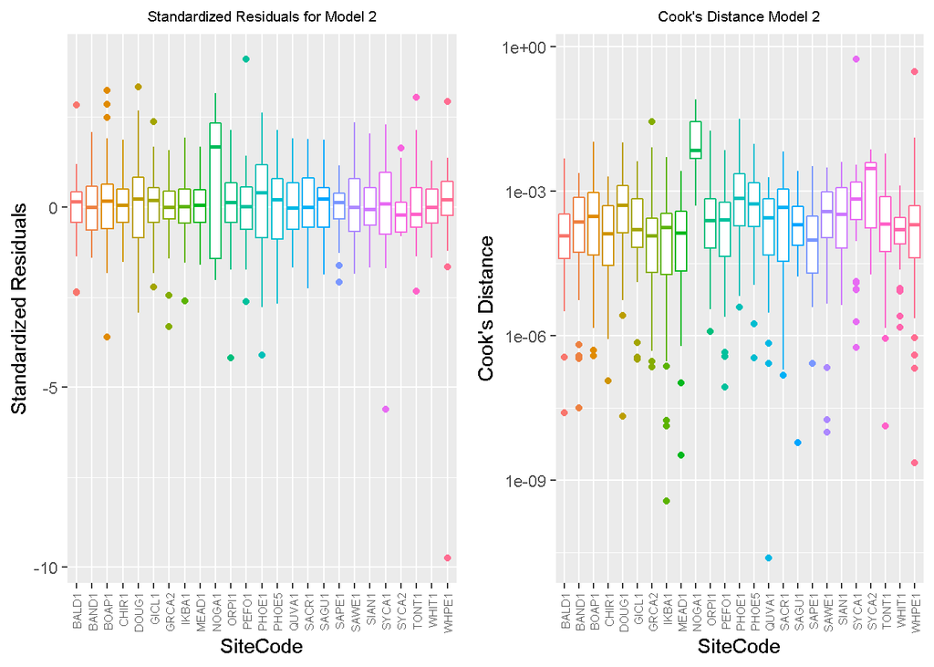

Figure A2.12: Side-by-Side boxplots for standardized residuals and Cook’s Distance for ‘Theoretical III’ model

```r
A3<-augment(fit_FO3) #Tidy extract fit diagnostic info
SW_DATA_A3<-add_column(SW_DATA,A3$.std.resid,A3$.cooksd)

Q1<-ggplot(SW_DATA_A2,aes(x=SiteCode,y=A3$.std.resid,color=SiteCode))+
  geom_boxplot()+
  theme(plot.title=element_text(hjust = 0.5,size=8))+
  theme(legend.position = "none",axis.text.x = element_text(angle = 90, vjust = 0.5, hjust=1,size=6))+ylab("Standardized Residuals")+ggtitle("Standardized Residuals for Model 2")
Q2<-ggplot(SW_DATA_A2,aes(x=SiteCode,y=A3$.cooksd,color=SiteCode))+
  geom_boxplot()+
  theme(plot.title=element_text(hjust = 0.5,size=8))+
  theme(legend.position = "none",axis.text.x = element_text(angle = 90, vjust = 0.5, hjust=1,size=6))+ylab("Cook's Distance")+scale_y_log10()+ggtitle("Cook's Distance Model 2")
grid.arrange(Q1,Q2,nrow=1)
```

##### — Comments on Model 3: —

— Side-by-Side boxplots —

— Rationale for Stepwise selection —

- To my knowledge, the literature doesn’t indicate any more chemical species that should influence fAbs. -Thus, stepwise selection is appropriate by considering all…
1. Trace elements (tracer compounds, Al, Si, etc.)
2. Non-proxy compounds, e.g., NO3 (nitrate) but not ammNO3 ammonium nitrate as ammonium was not directly measured. Specifically, all nitrate in the sample was ASSUMED to belong to ammonium nitrate. This is not necessarily a great approximation (in general) as sodium nitrate is also contained in aerosols. SOIL and SeaSalt are also excluded.
3. PM2.5 and PM10 are excluded. PM2.5 is just total mass of aerosol on the sample with diameters <2.5microns. As such, this variable CONTAINS EC, OC, OP, etc. PM10 contains all of PM2.5 and corresponds to all mass on the sample less than 10 microns.
4. Exclude OC and EC fraction (e.g., EC1, OC2, etc.). THese are simply used for QC purposes in the IMPROVE network as OC=OC_unadj+OP=OC1+OC2+OC3+OC4+OP and EC=EC_unadj-OP=EC1+EC2+EC3-OP

### — Part 5: Additive models with stepAIC —

```r
exclude_addl<-c("PM2.5","PM10","Date","POC","ammNO3","ammSO4","SeaSalt","SOIL","OC1","OC2","OC3","OC4","EC1","EC2","EC3","fAbs_MDL")
SW_DATA_LRG<- SW_DATA_LRG %>% dplyr::select(!contains(exclude_addl) & !matches("_UNC") | matches("fAbs_UNC"))

SW_DATA_LRG_test<- SW_DATA_LRG %>% dplyr::select(!contains(exclude_addl) & !matches("_UNC") | matches("fAbs_UNC"))

## --- Part E: Checking data integrity (NAs) ---

any(is.na(SW_DATA_LRG))
```

```
## [1] FALSE
```

```r
### ---- Let's remove any NA values from the datatable ----
SW_DATA_LRG<-SW_DATA_LRG[which(complete.cases(SW_DATA_LRG)),]

head(SW_DATA_LRG)
```

```
## # A tibble: 6 x 33
##   SiteCode  fAbs     EC    OC     OP      AL      AS      BR      CA      CL
##   <chr>    <dbl>  <dbl> <dbl>  <dbl>   <dbl>   <dbl>   <dbl>   <dbl>   <dbl>
## 1 BALD1     1.85 0.143  1.21  0.295  0.0177  0       0.00184 0.00918 5.30e-4
## 2 BALD1     0.7  0.0751 0.705 0.169  0.00306 0.00017 0.00079 0.00144 6.00e-4
## 3 BALD1     0.79 0.0927 0.644 0.152  0.00279 0       0.00053 0.00501 1.13e-3
## 4 BALD1     0.51 0.0942 0.375 0.0588 0.00297 0       0.00018 0.00267 6.60e-4
## 5 BALD1     0.24 0.018  0.164 0.045  0.00834 0       0.00081 0.00409 7.00e-5
## 6 BALD1     0.68 0.084  0.349 0.0532 0.00494 0       0.0005  0.00755 1.26e-3
## # ... with 23 more variables: CR <dbl>, CU <dbl>, FE <dbl>, PB <dbl>, MG <dbl>,
## #   MN <dbl>, NI <dbl>, NO3 <dbl>, N2 <dbl>, P <dbl>, K <dbl>, RB <dbl>,
## #   SE <dbl>, SI <dbl>, NA. <dbl>, SR <dbl>, SO4 <dbl>, S <dbl>, TI <dbl>,
## #   V <dbl>, ZN <dbl>, ZR <dbl>, fAbs_UNC <dbl>
```

```r
SW_DATA_LRG_test<-SW_DATA_LRG[ind_test,]
SW_DATA_LRG<-SW_DATA_LRG[-ind_test,]
```

```r
n<-nrow(SW_DATA_LRG)
w_ii<-1/(SW_DATA_LRG$fAbs_UNC^2) #Weights for WLS
EC_only_mod <- lm(fAbs~EC-1, data=SW_DATA_LRG,weights=w_ii)
full_mod <- lm(fAbs ~ . - fAbs -fAbs_UNC -1, data=SW_DATA_LRG,weights=w_ii)

## --- Let's use AIC ---
fit_FO4<-stepAIC(EC_only_mod,scope=list(upper=formula(full_mod), lower = formula(EC_only_mod)), direction="both", k=2, trace = FALSE)
summary(fit_FO4)
```

```
##
## Call:
## lm(formula = fAbs ~ EC + SI + SiteCode + OP + CU + FE + TI +
##     K + BR + NA. + MG + CA + NO3 + PB + CL + V + CR + N2 + AS +
##     AL + ZN + RB - 1, data = SW_DATA_LRG, weights = w_ii)
##
## Weighted Residuals:
##      Min       1Q   Median       3Q      Max
## -24.0508  -1.3102   0.1559   1.5108  11.3725
##
## Coefficients:
##                 Estimate Std. Error t value Pr(>|t|)
## EC             8.056e+00  1.856e-01  43.408  < 2e-16 ***
## SI            -2.490e+00  5.177e-01  -4.810 1.70e-06 ***
## SiteCodeBALD1 -2.240e-01  5.465e-02  -4.099 4.42e-05 ***
## SiteCodeBAND1 -2.536e-01  5.724e-02  -4.430 1.03e-05 ***
## SiteCodeBOAP1 -3.615e-03  6.295e-02  -0.057 0.954223
## SiteCodeCHIR1 -1.007e-01  5.586e-02  -1.803 0.071569 .
## SiteCodeDOUG1  6.847e-03  1.020e-01   0.067 0.946509
## SiteCodeGICL1 -2.627e-01  5.699e-02  -4.609 4.47e-06 ***
## SiteCodeGRCA2 -2.055e-01  5.487e-02  -3.745 0.000189 ***
## SiteCodeIKBA1 -1.478e-01  6.115e-02  -2.418 0.015764 *
## SiteCodeMEAD1 -7.840e-02  5.556e-02  -1.411 0.158477
## SiteCodeNOGA1  5.111e-01  2.331e-01   2.192 0.028546 *
## SiteCodeORPI1 -1.642e-01  6.087e-02  -2.698 0.007068 **
## SiteCodePEFO1 -1.954e-02  5.783e-02  -0.338 0.735517
## SiteCodePHOE1  4.620e-01  1.116e-01   4.139 3.72e-05 ***
## SiteCodePHOE5  5.669e-01  1.138e-01   4.980 7.28e-07 ***
## SiteCodeQUVA1 -2.410e-01  6.759e-02  -3.566 0.000376 ***
## SiteCodeSACR1 -2.716e-01  7.126e-02  -3.811 0.000145 ***
## SiteCodeSAGU1  6.569e-02  6.213e-02   1.057 0.290556
## SiteCodeSAPE1 -2.132e-01  5.765e-02  -3.698 0.000227 ***
## SiteCodeSAWE1  1.904e-01  6.571e-02   2.898 0.003820 **
## SiteCodeSIAN1 -1.520e-01  7.100e-02  -2.142 0.032424 *
## SiteCodeSYCA1 -2.387e-01  8.379e-02  -2.849 0.004455 **
## SiteCodeSYCA2 -1.992e-01  1.527e-01  -1.304 0.192405
## SiteCodeTONT1 -1.450e-01  6.342e-02  -2.287 0.022384 *
## SiteCodeWHIT1 -2.361e-01  5.600e-02  -4.217 2.66e-05 ***
## SiteCodeWHPE1 -2.527e-01  5.893e-02  -4.288 1.94e-05 ***
## OP             2.203e+00  1.774e-01  12.414  < 2e-16 ***
```

[output cut: 9 more lines]

```
## PB             5.509e+01  1.633e+01   3.374 0.000763 ***
## CL            -1.637e+00  6.069e-01  -2.697 0.007092 **
## V             -1.296e+02  5.213e+01  -2.487 0.013021 *
## CR            -2.189e+02  9.955e+01  -2.198 0.028109 *
## N2             9.726e-01  4.852e-01   2.005 0.045229 *
## AS            -3.992e+01  2.091e+01  -1.910 0.056429 .
## AL             1.676e+00  1.043e+00   1.607 0.108329
## ZN            -4.394e+00  2.890e+00  -1.520 0.128650
## RB            -9.724e+01  6.476e+01  -1.502 0.133455
## ---
## Signif. codes:  0 '***' 0.001 '**' 0.01 '*' 0.05 '.' 0.1 ' ' 1
##
## Residual standard error: 2.541 on 1218 degrees of freedom
## Multiple R-squared:  0.961,  Adjusted R-squared:  0.9595
## F-statistic: 652.2 on 46 and 1218 DF,  p-value: < 2.2e-16
```

```r
formula(fit_FO4)
```

```
## fAbs ~ EC + SI + SiteCode + OP + CU + FE + TI + K + BR + NA. +
##     MG + CA + NO3 + PB + CL + V + CR + N2 + AS + AL + ZN + RB -
##     1
```

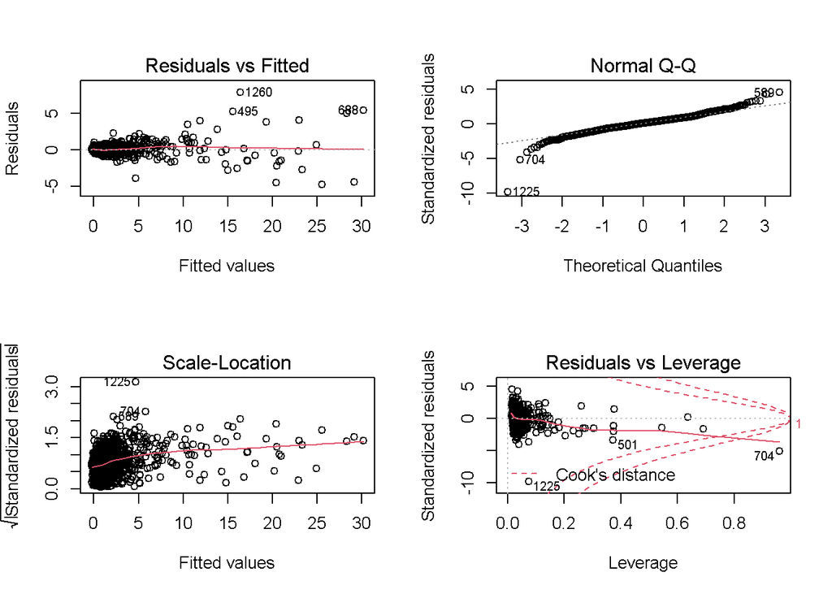

Figure A2.13: diagnostic plots for ‘First order stepAIC’ model

```r
par(mfrow=c(2,2))
plot(fit_FO4)
```

```r
glance(fit_FO4)
```

```
## # A tibble: 1 x 12
##   r.squared adj.r.squared sigma statistic p.value    df logLik   AIC   BIC
##       <dbl>         <dbl> <dbl>     <dbl>   <dbl> <dbl>  <dbl> <dbl> <dbl>
## 1     0.961         0.960  2.54      652.       0    46  -704. 1502. 1744.
## # ... with 3 more variables: deviance <dbl>, df.residual <int>, nobs <int>
```

```r
anova(fit_FO4)
```

```
## Analysis of Variance Table
##
## Response: fAbs
##             Df Sum Sq Mean Sq    F value    Pr(>F)
## EC           1 178578  178578 27654.6800 < 2.2e-16 ***
## SI           1   8690    8690  1345.7800 < 2.2e-16 ***
## SiteCode    25   2937     117    18.1921 < 2.2e-16 ***
## OP           1   1313    1313   203.3163 < 2.2e-16 ***
## CU           1    339     339    52.5719 7.352e-13 ***
## FE           1    254     254    39.3031 5.028e-10 ***
## TI           1    509     509    78.7625 < 2.2e-16 ***
## K            1    229     229    35.5212 3.299e-09 ***
## BR           1    119     119    18.4123 1.920e-05 ***
## NA.          1     77      77    11.9882 0.0005539 ***
## MG           1    250     250    38.6779 6.857e-10 ***
## CA           1    134     134    20.7299 5.818e-06 ***
## NO3          1     54      54     8.3701 0.0038823 **
## PB           1     37      37     5.6940 0.0171750 *
## CL           1     32      32     4.9964 0.0255815 *
## V            1     41      41     6.2934 0.0122479 *
## CR           1     35      35     5.4874 0.0193146 *
## N2           1     29      29     4.4522 0.0350602 *
## AS           1     21      21     3.2941 0.0697740 .
## AL           1     18      18     2.8451 0.0919110 .
## ZN           1     15      15     2.3266 0.1274357
## RB           1     15      15     2.2549 0.1334552
## Residuals 1218   7865       6
## ---
## Signif. codes:  0 '***' 0.001 '**' 0.01 '*' 0.05 '.' 0.1 ' ' 1
```

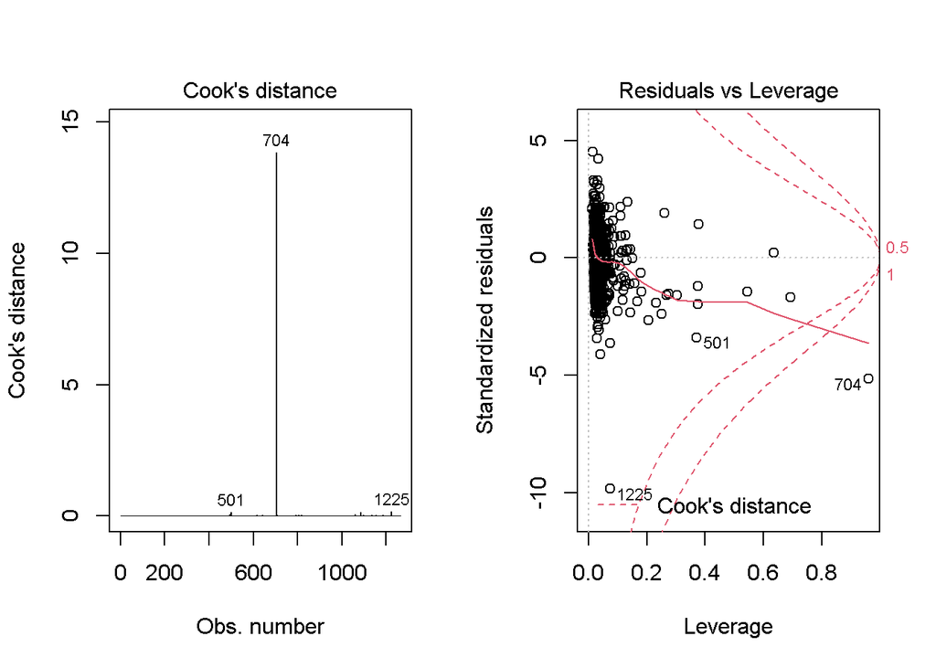

Figure A2.14: diagnostic plots for ‘First order stepAIC’ model (zoomed in)

```r
A4<-augment(fit_FO4)
## --- Let's just look at residuals ---
# --- Let's look at cook's distance...
#plot(fit_FO4, which=1)
par(mfrow=c(1,2))
plot(fit_FO4, which=4)
plot(fit_FO4, which=5)
```

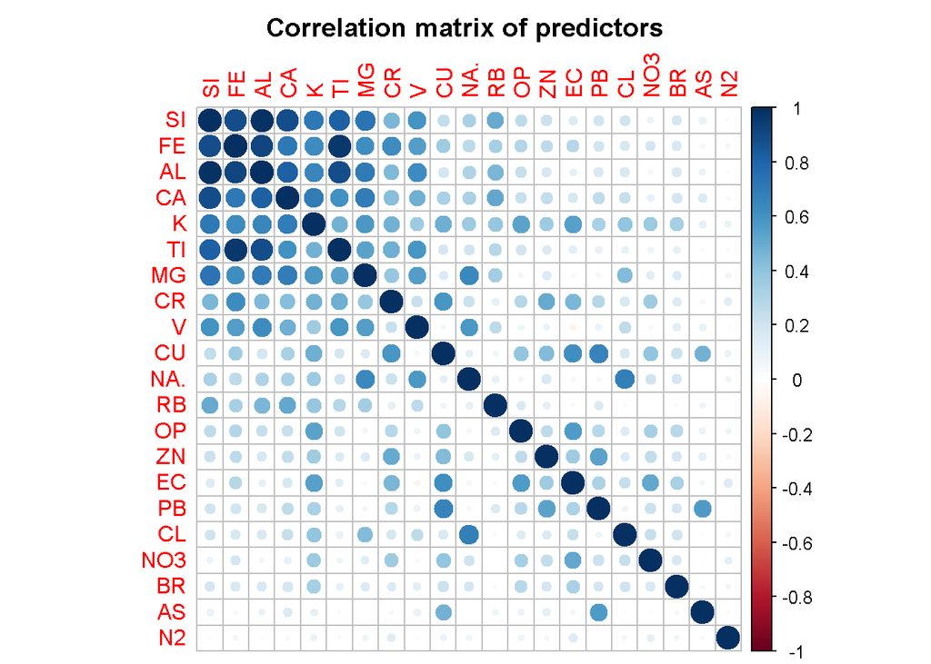

Figure A2.15: Coorplot for ‘First order stepAIC’ model selected predictors

```r
## --- Let's look at corrplot of selected species
stepAIC_vars1<-attr(fit_FO4$terms,"term.labels")
stepAIC_vars<-stepAIC_vars1[stepAIC_vars1 != "SiteCode"]
SW_DATA_step<-SW_DATA_LRG %>%
  dplyr::select(all_of(stepAIC_vars))
R_AIC<-cor(SW_DATA_step)
corrplot(R_AIC,title="Correlation matrix of predictors",mar=c(0,0,2,0),order="FPC",pch.cex=0.75)
```